# VS2.3 - Illustration of PCDs in One Tetrahedron

Elvan Ceyhan

2023-12-18

First we load the `pcds` package:

```r
library(pcds)
```

# 1 Functions for PCDs with Vertices in One Tetrahedron

For illustration of construction of PCDs and related quantities, we first focus on one Delaunay cell, which is a tetrahedron in the 3D setting. Due to geometry invariance of PE- and CS-PCDs with vertices from uniform distribution in a tetrahedron in $\mathbb R^3$, most data generation and computations can be done in the *standard regular tetrahedron*, and for AS-PCD, one can restrict attention to the *basic tetrahedron*. Here, we only consider the PE-PCD with vertices being 3D data points, extension of the other PCDs is left for future work. The *standard regular tetrahedron* is $T_{reg}=T(A,B,C,D)$ with vertices $A=(0,0,0)$, $B=(1,0,0)$, and $C=\left(1/2,\sqrt{3}/2,0\right)$, and $D=\left(1/2,\sqrt{3}/6,\sqrt{6}/3\right)$.

For more detail on the extension of PCDs to higher dimensions, see Ceyhan (2005), Ceyhan, Priebe, and Wierman (2006), Ceyhan, Priebe, and Marchette (2007), and Ceyhan and Priebe (2007).

We first choose an arbitrary tetrahedron. We choose the arbitrary tetrahedron $T=T(A,B,C,D)$ with vertices jittered around the vertices of the standard regular tetrahedron (for better visualization).

```r
set.seed(1)
A<-c(0,0,0)+runif(3,-.25,.25);
B<-c(1,0,0)+runif(3,-.25,.25);
C<-c(1/2,sqrt(3)/2,0)+runif(3,-.25,.25);
D<-c(1/2,sqrt(3)/6,sqrt(6)/3)+runif(3,-.25,.25)
tetra<-rbind(A,B,C,D)
n<-5  #try also n<-10 or 20
```

And we generate $n=$ 5 $\mathcal{X}$ points uniformly in the tetrahedron $T$ using the function `runif.tetra` in `pcds`. One can use the center of mass (default) or the circumcenter of the tetrahedron to construct the vertex regions. $\mathcal{X}$ points are denoted as `Xp` and $\mathcal{Y}$ points correspond to the vertices of the tetrahedron $T$ (i.e. $\{A,B,C,D\}$).

```r
Xp<-runif.tetra(n,tetra)$g  #try also Xp[,1]<-Xp[,1]+1
```

Plot of the tetrahedron $T$ and the $\mathcal{X}$ points in it, and we also add the vertex names using the `text3D` function from package `plot3D`.

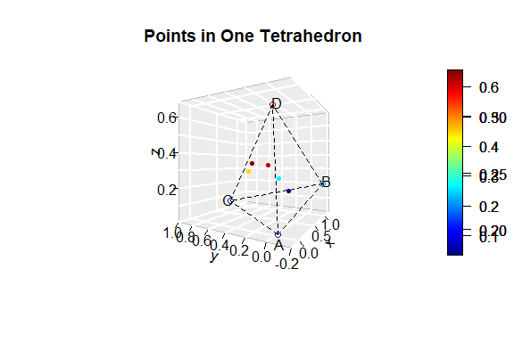

Figure 1.1: Scatterplot of the uniform $X$ points in the tetrahedron $T$.

```r
xlim<-range(tetra[,1],Xp[,1])
ylim<-range(tetra[,2],Xp[,2])
zlim<-range(tetra[,3],Xp[,3])

xr<-xlim[2]-xlim[1]
yr<-ylim[2]-ylim[1]
zr<-zlim[2]-zlim[1]

plot3D::scatter3D(Xp[,1],Xp[,2],Xp[,3], phi=0,theta=-60, bty = "g",main="Points in One Tetrahedron",
                  xlab="x", ylab="y", zlab="z", xlim=xlim+xr*c(-.05,.05), ylim=ylim+yr*c(-.05,.05),
                  zlim=zlim+zr*c(-.05,.05), pch = 20, cex = 1, ticktype = "detailed")
#add the vertices of the tetrahedron
plot3D::points3D(tetra[,1],tetra[,2],tetra[,3], add = TRUE)
A<-tetra[1,]; B<-tetra[2,]; C<-tetra[3,]; D<-tetra[4,]
L<-rbind(A,A,A,B,B,C); R<-rbind(B,C,D,C,D,D)
plot3D::segments3D(L[,1], L[,2], L[,3], R[,1], R[,2],R[,3], add=TRUE,lwd=1,lty=2)
#now we add the vertex names and annotation
txt<-tetra
xc<-txt[,1]+c(-.02,.02,-.15,.02)
yc<-txt[,2]+c(.02,.02,.02,.02)
zc<-txt[,3]+c(-.04,.02,.02,.02)
txt.str<-c("A","B","C","D")
plot3D::text3D(xc,yc,zc,txt.str, add = TRUE)
```

## 1.1 Functions for Proportional Edge PCDs with Vertices in One Tetrahedron

We use the same tetrahedron $T$ and the generated data above, and choose the expansion parameter $r=1.5$ and center `M="CM"` to illustrate the PE proximity region construction.

The function `NPEtetra` is used for the construction of PE proximity regions taking the arguments `p,th,r,M,rv` where

- `p`, a 3D point whose PE proximity region is to be computed,
- `r`, a positive real number which serves as the expansion parameter in PE proximity region; must be $\ge 1$.
- `th`, A $4 \times 3$ matrix with each row representing a vertex of the tetrahedron,
- `M`, the center to be used in the construction of the vertex regions in the tetrahedron, `th`, Currently it only takes `"CC"` for circumcenter and `"CM"` for center of mass; default=`"CM"`,
- `rv`, the index of the vertex region containing the point, either `1,2,3,4` (default is `NULL`).

`NPEtetra` returns the proximity region as the the vertices of the tetrahedron proximity region.

```r
M<-"CM"  #try also M<-"CC"
r<-1.5
NPEtetra(Xp[1,],tetra,r)  #uses the default M="CM"
```

```
#>            [,1]      [,2]       [,3]
#> [1,] 0.72233763 0.9464243 0.06455702
#> [2,] 0.06169821 0.1514047 0.04242222
#> [3,] 1.10142305 0.0843472 0.17049892
#> [4,] 0.37498004 0.3131847 0.52897936
```

Indicator for the presence of an arc from a (data or $\mathcal{X}$) point to another for PE-PCDs is the function `IarcPEtetra` which takes arguments `p1,p2,th,r,M,rv` where

- `p1`, a 3D point whose PE proximity region is constructed.
- `p2`, a 3D point. The function determines whether `p2` is inside the PE proximity region of `p1` or not.
- `th,r,M,rv` are as in `NPEtetra`.

This function returns $I(p_2 \in N_{PE}(p_1,r))$, that is, returns 1 if `p2` is in $N_{PE}(p_1,r)$, 0 otherwise. One can use it for points in the data set or for arbitrary points (as if they were in the data set).

```r
IarcPEtetra(Xp[1,],Xp[2,],tetra,r)  #uses the default M="CM"
```

```
#> [1] 1
```

```r
IarcPEtetra(Xp[2,],Xp[1,],tetra,r,M)
```

```
#> [1] 1
```

Number of arcs of the PE-PCD can be computed by the function `num.arcsPEtetra`, which is an object of class “`NumArcs`” and takes arguments `Xp,th,r,M` where `Xp` is the data set, and `th,r,M` are as in `NPEtetra`. This function returns the list of

- `desc`: A description of the PCD and the output
- `num.arcs`: Number of arcs of the PE-PCD,
- `num.in.tetra`: Number of `Xp` points in the tetrahedron `tetra`,
- `ind.in.tetra`: The vector of indices of the `Xp` points that reside in the tetrahedron.
- `tess.points`: Vertices of the tetrahedron (i.e. `Yp` points)
- `vertices`: vertices of the PCD (i.e. `Xp` points)

The output is as in `num.arcsPEtri`.

```r
Narcs = num.arcsPEtetra(Xp,tetra,r,M)
summary(Narcs)
```

```
#> Call:
#> num.arcsPEtetra(Xp = Xp, th = tetra, r = r, M = M)
#>
#> Description of the output:
#> Number of Arcs of the PE-PCD with vertices Xp and Quantities Related to the Support Tetrahedron
#>
#> Number of data (Xp) points in the tetrahedron =  5
#> Number of arcs in the digraph =  10
#>
#> Indices of data points in the tetrahedron:
#> 1 2 3 4 5
#>
```

```r
#plot(Narcs) #gives error
```

The arc density of the PE-PCD can be computed by the function `PEarc.dens.tetra`. It takes the arguments `Xp,th,r,M,th.cor` where `Xp,th,r,M` are as in `num.arcsPEtetra` and `th.cor` is a logical argument for computing the arc density for only the points inside the tetrahedron, `th`. (default is `th.cor=FALSE`), i.e., if `th.cor=TRUE` only the induced digraph with the vertices inside `th` are considered in the computation of arc density. Arc density can be adjusted (or corrected) for the points outside the triangle by using the option `th.cor=TRUE`.

```r
PEarc.dens.tetra(Xp,tetra,r,M)
```

```
#> [1] 0.5
```

The incidence matrix of the PE-PCD for the one tetrahedron case can be found by `inci.matPEtetra`, using the `inci.matPEtetra(Xp,tetra,r,M)` command. It has the same arguments as `num.arcsPEtetra` function.

Plots of the PE proximity region for one of the $\mathcal{X}$ points only (for better visualization).

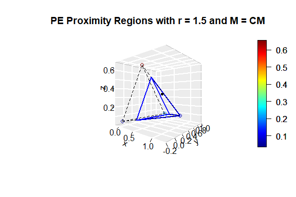

Figure 1.2: PE proximity regions for one of the $X$ points in the tetrahedron $T$ for better visualization.

```r
plotPEregs.tetra(Xp[1,],tetra,r=1.5)  #uses the default M="CM"
```

## 1.2 Functions for Construction and Simulation of Proportional Edge PCDs in the Standard Regular Tetrahedron

We first define the standard regular tetrahedron $T_{reg}$ as in Section 1.

```r
A<-c(0,0,0); B<-c(1,0,0); C<-c(1/2,sqrt(3)/2,0); D<-c(1/2,sqrt(3)/6,sqrt(6)/3)
tetra<-rbind(A,B,C,D)

n<-10  #try also n<-20
```

```r
Xp<-runif.std.tetra(n)$g
```

Plot of the standard regular tetrahedron $T_{reg}$ and the $\mathcal{X}$ points in it are provided using the below code. We also add the vertex names using the `text3D` function from package `plot3D`.

```r
xlim<-range(tetra[,1],Xp[,1])
ylim<-range(tetra[,2],Xp[,2])
zlim<-range(tetra[,3],Xp[,3])

xr<-xlim[2]-xlim[1]
yr<-ylim[2]-ylim[1]
zr<-zlim[2]-zlim[1]

plot3D::scatter3D(Xp[,1],Xp[,2],Xp[,3], phi=0,theta=-60, bty = "g",main="Points in the Standard Regular Tetrahedron",
                  xlab="x", ylab="y", zlab="z", xlim=xlim+xr*c(-.05,.05), ylim=ylim+yr*c(-.05,.05),
                  zlim=zlim+zr*c(-.05,.05), pch = 20, cex = 1, ticktype = "detailed")
#add the vertices of the tetrahedron
plot3D::points3D(tetra[,1],tetra[,2],tetra[,3], add = TRUE)
A<-tetra[1,]; B<-tetra[2,]; C<-tetra[3,]; D<-tetra[4,]
L<-rbind(A,A,A,B,B,C); R<-rbind(B,C,D,C,D,D)
plot3D::segments3D(L[,1], L[,2], L[,3], R[,1], R[,2],R[,3], add=TRUE,lwd=1,lty=2)

#now we add the vertex names and annotation
txt<-tetra
xc<-txt[,1]+c(-.01,.02,-.12,.02)
yc<-txt[,2]+c(.02,.02,.02,-.01)
zc<-txt[,3]+c(-.04,.02,.02,.02)
txt.str<-c("A","B","C","D")
plot3D::text3D(xc,yc,zc,txt.str, add = TRUE)
```

[output not shown]

The function `NPEstd.tetra` is used for the construction of PE proximity regions for points in $T_{reg}$ taking arguments `p,r,rv` which are same as in `NPEtetra`. This function returns the proximity region as the the vertices of the tetrahedron proximity region. Center of mass is equivalent to circumcenter for $T_{reg}$, so no argument is specified for the center.

```r
r<-1.5
NPEstd.tetra(Xp[1,],r)
```

```
#>           [,1]      [,2]      [,3]
#> [1,] 0.5000000 0.8660254 0.0000000
#> [2,] 0.1618881 0.2803983 0.0000000
#> [3,] 0.5000000 0.4756074 0.5521345
#> [4,] 0.8381119 0.2803983 0.0000000
```

```r
NPEstd.tetra(Xp[5,],r)
```

```
#>            [,1]      [,2]      [,3]
#> [1,] 1.00000000 0.0000000 0.0000000
#> [2,] 0.52499658 0.8227301 0.0000000
#> [3,] 0.52499658 0.2742434 0.7756773
#> [4,] 0.04999316 0.0000000 0.0000000
```

Indicator for the presence of an arc from a (data or $\mathcal{X}$) point to another for PE-PCDs is the function `IarcPEstd.tetra` which takes arguments `p1,p2,r,rv` and returns $I(p_2 \in N_{PE}(p_1,r))$ which are same as in `IarcPEtetra`. One can use it for points in the data set or for arbitrary points (as if they were in the data set).

```r
IarcPEstd.tetra(Xp[1,],Xp[3,],r)  #uses the default M="CM"
```

```
#> [1] 1
```

Plots of the PE proximity regions for all points can be obtained with the below code:

```r
plotPEregs.std.tetra(Xp,r)
```

[output not shown]

## 1.3 Auxiliary Functions to Define Proximity Regions for Points in a Tetrahedron

We only use circumcenter (CC) or center of mass (CM) to construct vertex regions in a tetrahedron, and here we illustrate finding CC (as CM is just the componentwise arithmetic average of the vertices) of a tetrahedron. The function `circumcenter.tetra` takes the sole argument `th` for a $4 \times 3$ matrix with each row representing a vertex of the tetrahedron and returns the circumcenter of a general tetrahedron. We use a tetrahedron $T$ whose vertices are jittered around the vertices of a standard regular tetrahedron for better visualization in the plots.

```r
set.seed(123)
A<-c(0,0,0)+runif(3,-.2,.2);
B<-c(1,0,0)+runif(3,-.2,.2);
C<-c(1/2,sqrt(3)/2,0)+runif(3,-.2,.2);
D<-c(1/2,sqrt(3)/6,sqrt(6)/3)+runif(3,-.2,.2);
tetra<-rbind(A,B,C,D)

CC<-circumcenter.tetra(tetra)
CC
```

```
#> [1] 0.5516851 0.3386671 0.1212977
```

We can also illustrate the CC in a tetrahedron in a plot with vertex and CC annotation. Type `? circumcenter.tetra` for the code to generate the corresponding figure.

The function `rel.vert.tetraCC` takes arguments `p,th` and returns the index of the $CC$-vertex region in a tetrahedron `th` where the point `p` resides.

```r
n<-10  #try also n<-20
Xp<-runif.tetra(n,tetra)$g
rel.vert.tetraCC(Xp[1,],tetra)
```

```
#> $rv
#> [1] 2
#>
#> $tetra
#>                 [,1]      [,2]        [,3]
#> vertex 1 -0.08496899 0.1153221 -0.03640923
#> vertex 2  1.15320696 0.1761869 -0.18177740
#> vertex 3  0.51124220 1.0229930  0.02057401
#> vertex 4  0.48264589 0.4714085  0.79783024
```

```r
Rv<-vector()
for (i in 1:n)
  Rv<-c(Rv,rel.vert.tetraCC(Xp[i,],tetra)$rv)
Rv
```

```
#>  [1] 2 2 1 3 2 1 2 3 2 1
```

We illustrate the CC-vertex regions using the following code. We annotate the vertices and CC and provide the scatterplot of these points labeled according to the vertex region they reside in. Type also `? rel.vert.tetraCC` for the code to generate this figure.

```r
CC<-circumcenter.tetra(tetra)
CC

Xlim<-range(tetra[,1],Xp[,1],CC[1])
Ylim<-range(tetra[,2],Xp[,2],CC[2])
Zlim<-range(tetra[,3],Xp[,3],CC[3])
xd<-Xlim[2]-Xlim[1]
yd<-Ylim[2]-Ylim[1]
zd<-Zlim[2]-Zlim[1]

plot3D::scatter3D(tetra[,1],tetra[,2],tetra[,3], phi =0,theta=40, bty = "g",
                  main="Scatterplot of data points with CC-vertex regions",
                  xlim=Xlim+xd*c(-.05,.05),ylim=Ylim+yd*c(-.05,.05), zlim=Zlim+zd*c(-.05,.05),
                  pch = 20, cex = 1, ticktype = "detailed")
L<-rbind(A,A,A,B,B,C); R<-rbind(B,C,D,C,D,D)
plot3D::segments3D(L[,1], L[,2], L[,3], R[,1], R[,2],R[,3], add=TRUE,lwd=2)
#add the data points
plot3D::points3D(Xp[,1],Xp[,2],Xp[,3],pch=".",cex=3, add=TRUE)

plot3D::text3D(tetra[,1],tetra[,2],tetra[,3], labels=c("A","B","C","D"), add=TRUE)
plot3D::text3D(CC[1],CC[2],CC[3], labels=c("CC"), add=TRUE)

D1<-(A+B)/2; D2<-(A+C)/2; D3<-(A+D)/2; D4<-(B+C)/2; D5<-(B+D)/2; D6<-(C+D)/2;
L<-rbind(D1,D2,D3,D4,D5,D6); R<-matrix(rep(CC,6),ncol=3,byrow=TRUE)
plot3D::segments3D(L[,1], L[,2], L[,3], R[,1], R[,2],R[,3], add=TRUE,lty=2)

F1<-intersect.line.plane(A,CC,B,C,D)
L<-matrix(rep(F1,4),ncol=3,byrow=TRUE); R<-rbind(D4,D5,D6,CC)
plot3D::segments3D(L[,1], L[,2], L[,3], R[,1], R[,2],R[,3],col=2, add=TRUE,lty=2)

F2<-intersect.line.plane(B,CC,A,C,D)
L<-matrix(rep(F2,4),ncol=3,byrow=TRUE); R<-rbind(D2,D3,D6,CC)
plot3D::segments3D(L[,1], L[,2], L[,3], R[,1], R[,2],R[,3],col=3, add=TRUE,lty=2)

F3<-intersect.line.plane(C,CC,A,B,D)
L<-matrix(rep(F3,4),ncol=3,byrow=TRUE); R<-rbind(D3,D5,D6,CC)
plot3D::segments3D(L[,1], L[,2], L[,3], R[,1], R[,2],R[,3],col=4, add=TRUE,lty=2)

F4<-intersect.line.plane(D,CC,A,B,C)
L<-matrix(rep(F4,4),ncol=3,byrow=TRUE); R<-rbind(D1,D2,D4,CC)
plot3D::segments3D(L[,1], L[,2], L[,3], R[,1], R[,2],R[,3],col=5, add=TRUE,lty=2)

plot3D::text3D(Xp[,1],Xp[,2],Xp[,3], labels=factor(Rv), add=TRUE)
```

[output not shown]

The function `rel.vert.tetraCM` takes the same arguments as `rel.vert.tetraCC` and returns the index of the $CM$-vertex region in a tetrahedron `th` where the point `p` resides. We use standard regular tetrahedron in this example.

```r
#The index of the $CM$-vertex region in a tetrahedron that contains a point
A<-c(0,0,0); B<-c(1,0,0); C<-c(1/2,sqrt(3)/2,0); D<-c(1/2,sqrt(3)/6,sqrt(6)/3)
tetra<-rbind(A,B,C,D)

n<-10  #try also n<-20
Xp<-runif.std.tetra(n)$g
rel.vert.tetraCM(Xp[1,],tetra)
```

```
#> $rv
#> [1] 4
#>
#> $tetra
#>          [,1]      [,2]      [,3]
#> vertex 1  0.0 0.0000000 0.0000000
#> vertex 2  1.0 0.0000000 0.0000000
#> vertex 3  0.5 0.8660254 0.0000000
#> vertex 4  0.5 0.2886751 0.8164966
```

```r
Rv<-vector()
for (i in 1:n)
  Rv<-c(Rv, rel.vert.tetraCM(Xp[i,],tetra)$rv )
Rv
```

```
#>  [1] 4 4 3 4 4 1 1 3 3 2
```

We can also illustrate the CC in a tetrahedron in a plot with vertex and CC annotation. Type `? rel.vert.tetraCM` for the code to generate the corresponding figure.

# References

Ceyhan, E. 2005. “An Investigation of Proximity Catch Digraphs in Delaunay Tessellations, Also Available as Technical Monograph Titled Proximity Catch Digraphs: Auxiliary Tools, Properties, and Applications.” PhD thesis, The Johns Hopkins University, Baltimore, MD, 21218.

Ceyhan, E., and C. E. Priebe. 2007. “On the Distribution of the Domination Number of a New Family of Parametrized Random Digraphs.” *Model Assisted Statistics and Applications* 1(4): 231–55.

Ceyhan, E., C. E. Priebe, and D. J. Marchette. 2007. “A New Family of Random Graphs for Testing Spatial Segregation.” *Canadian Journal of Statistics* 35(1): 27–50.

Ceyhan, E., C. E. Priebe, and J. C. Wierman. 2006. “Relative Density of the Random $r$-Factor Proximity Catch Digraphs for Testing Spatial Patterns of Segregation and Association.” *Computational Statistics & Data Analysis* 50(8): 1925–64.